# Assignment 2: Calculations

## 6. **Total person’s income**: PINCP in o50people_data

```r
o50people_summary <- summary(o50people_data$PINCP)
o50people_summary
```

Mean

```r
mean(o50people_data$PINCP)
```

Sample Standard Deviation

```r
sd(o50people_data$PINCP)
```

95-percent Confidence Interval

```r
conf_int <- t.test(o50people_data$PINCP)
conf_int
```

Center of 95-percent Confidence Interval

```r
conf_int$estimate
```

Histogram

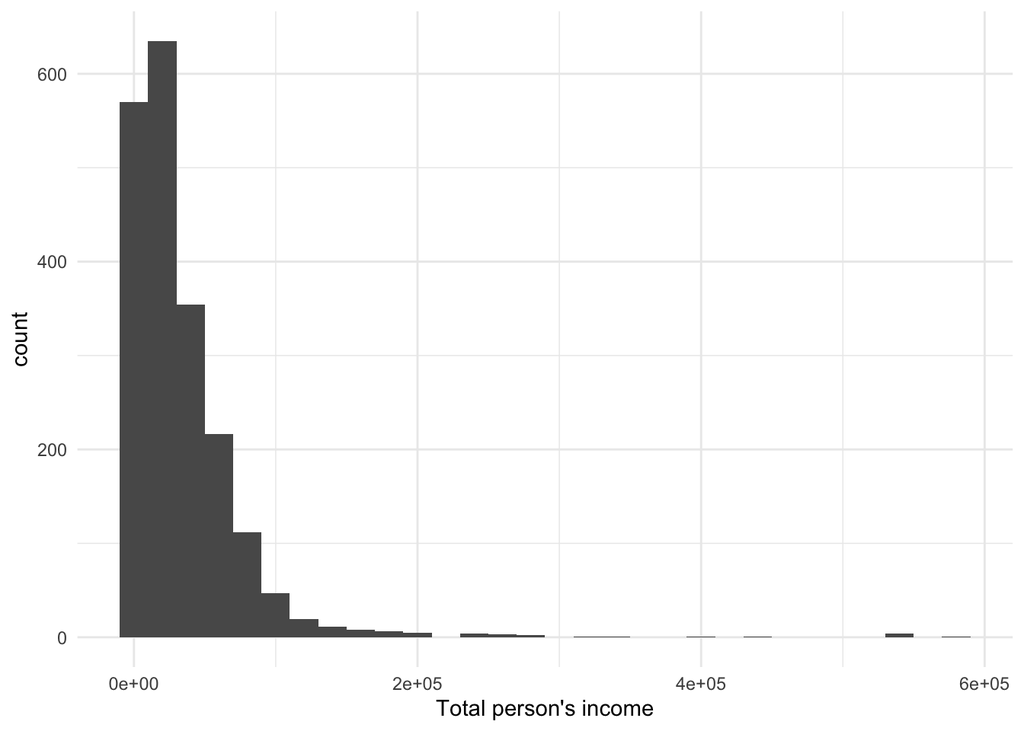

```r
ggplot(o50people_data, aes(x = PINCP)) +
  geom_histogram() +
 scale_x_continuous(name = "Total person's income") +
   theme_minimal()
```

# Categorical variables - Proportions

## 2. **School Enrollment**: SCH_label in u18people_data

Possible Values

```r
unique(u18people_data$SCH_label)
```

Number of Observations

```r
table(u18people_data$SCH_label)
```

Proportions of Observations

```r
table(u18people_data$SCH_label) / sum(table(u18people_data$SCH_label))
```

95-percent Confidence Interval of each category

N/A (less than 3 years old)

```r
t.test(u18people_data$SCH_label == "N/A (less than 3 years old)")
```

No, has not attended in the last 3 months

```r
t.test(u18people_data$SCH_label == "No, has not attended in the last 3 months)")
```

Yes, private school or college or home school

```r
t.test(u18people_data$SCH_label == "Yes, private school or college or home school")
```

Yes, public school or public college

```r
t.test(u18people_data$SCH_label == "Yes, public school or public college")
```

## 3. **Grade Level Attending**: SCHG_label in u18people_data

Possible Values

```r
unique(u18people_data$SCHG_label)
```

Number of Observations

```r
table(u18people_data$SCHG_label)
```

Proportions of Observations

```r
table(u18people_data$SCHG_label) / sum(table(u18people_data$SCHG_label))
```

95-percent Confidence Interval of each category

N/A (not attending school)

```r
t.test(u18people_data$SCHG_label == "N/A (not attending school)")
```

Nursery school/preschool

```r
t.test(u18people_data$SCHG_label == "Nursery school/preschool")
```

Kindergarten

```r
t.test(u18people_data$SCHG_label == "Kindergarten")
```

Grade 1

```r
t.test(u18people_data$SCHG_label == "Grade 1")
```

Grade 2

```r
t.test(u18people_data$SCHG_label == "Grade 2")
```

```r
t.test(u18people_data$SCHG_label == "Grade 1")
```

Grade 4

```r
t.test(u18people_data$SCHG_label == "Grade 4")
```

Grade 5

```r
t.test(u18people_data$SCHG_label == "Grade 5")
```

Grade 6

```r
t.test(u18people_data$SCHG_label == "Grade 6")
```

Grade 7

```r
t.test(u18people_data$SCHG_label == "Grade 7")
```

Grade 8

```r
t.test(u18people_data$SCHG_label == "Grade 8")
```

Grade 9

```r
t.test(u18people_data$SCHG_label == "Grade 9")
```

Grade 10

```r
t.test(u18people_data$SCHG_label == "Grade 10")
```

Grade 11

```r
t.test(u18people_data$SCHG_label == "Grade 11")
```

Grade 12

```r
t.test(u18people_data$SCHG_label == "Grade 12")
```

## 4. **Self-care difficulty**

```
4.1 Self-care difficulty in population under 18 within tract: FDDRSP_label in u18people_data
```

Possible Values

```r
unique(u18people_data$FDDRSP_label)
```

Number of Observations

```r
table(u18people_data$FDDRSP_label)
```

Proportions of Observations

```r
table(u18people_data$FDDRSP_label) / sum(table(u18people_data$FDDRSP_label))
```

95-percent Confidence Interval of each category

No

```r
t.test(u18people_data$FDDRSP_label == "No")
```

Yes

```r
t.test(u18people_data$FDDRSP_label == "Yes")
```

[output not shown]

Possible Values

```r
unique(o50people_data$FDDRSP_label)
```

Number of Observations

```r
table(o50people_data$FDDRSP_label)
```

Proportions of Observations

```r
table(o50people_data$FDDRSP_label) / sum(table(o50people_data$FDDRSP_label))
```

95-percent Confidence Interval of each category

No

```r
t.test(o50people_data$FDDRSP_label == "No")
```

Yes

```r
t.test(o50people_data$FDDRSP_label == "Yes")
```

## 5. **Grandparents responsible for grandchildren**:

Possible Values

```r
unique(o50people_data$GCR_label)
```

Number of Observations

```r
table(o50people_data$GCR_label)
```

Proportions of Observations

```r
table(o50people_data$GCR_label) / sum(table(o50people_data$GCR_label))
```

95-percent Confidence Interval of each category

No

```r
t.test(o50people_data$GCR_label == "No")
```

Yes

```r
t.test(o50people_data$GCR_label == "Yes")
```